# First Visualization And ggplot Basics

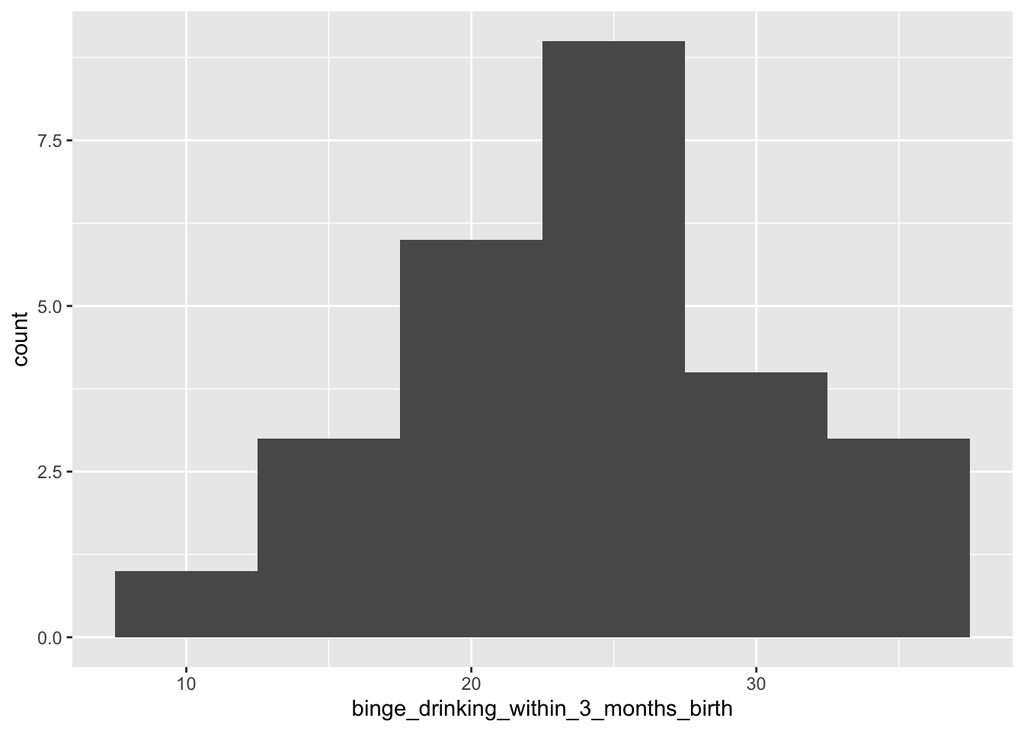

```r
p3 <- p2 +
  geom_histogram(binwidth = 5)

p3
```

Add labels.

| Plot component | Code in this chunk |
| --- | --- |
| Scales / coordinates / facets / labels | `labs()` |

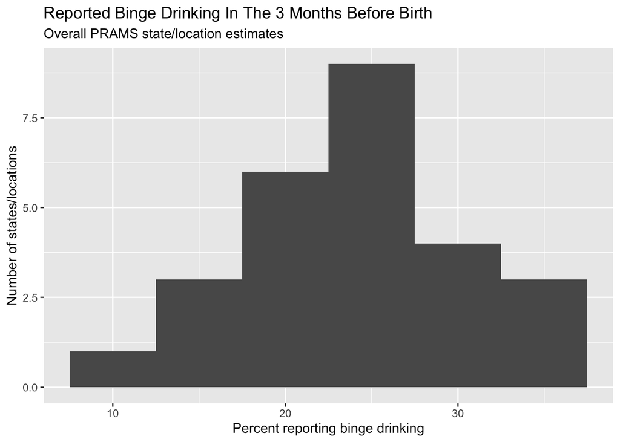

```r
p4 <- p3 +
  labs(
    title = "Reported Binge Drinking In The 3 Months Before Birth",
    subtitle = "Overall PRAMS state/location estimates",
    x = "Percent reporting binge drinking",
    y = "Number of states/locations"
  )

p4
```

Add a theme.

| Plot component | Code in this chunk |
| --- | --- |
| Scales / coordinates / facets / labels | `theme_minimal()` |

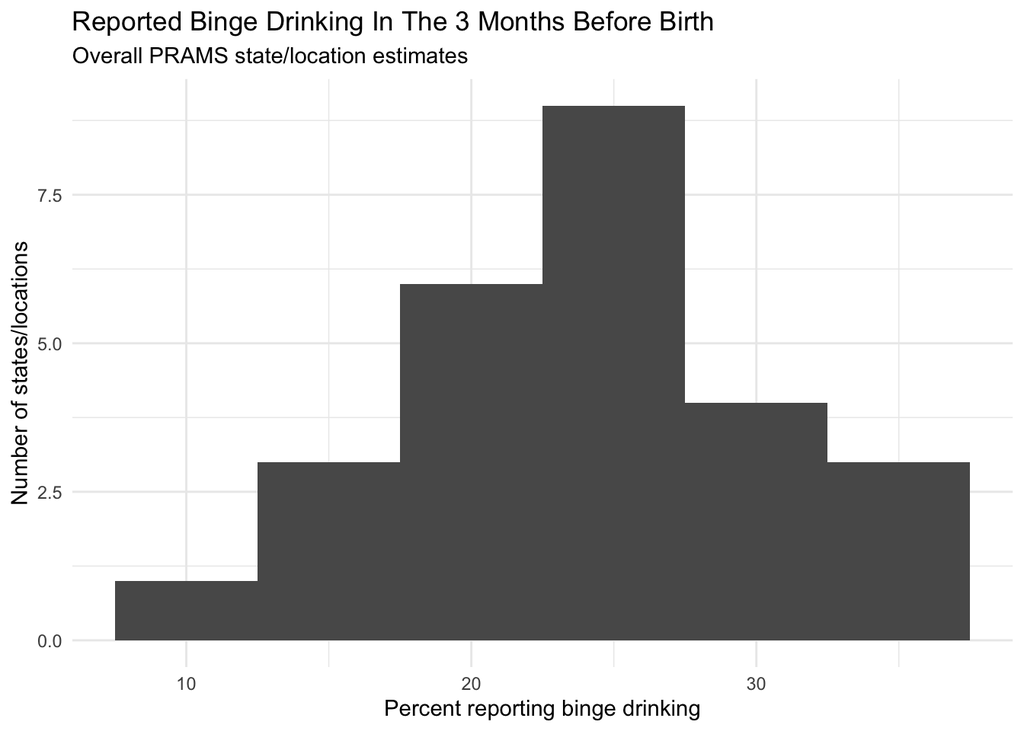

```r
p5 <- p4 +
  theme_minimal()

p5
```

# Plot 2: Compare Categories

Question: which states or locations have higher overall reported binge drinking estimates?

First, make a small table for the comparison.

| Data preparation step | Functions in this chunk |
| --- | --- |
| Choose or rename columns | `select()` |
| Sort rows | `arrange()`; `desc()` |

```r
prams_binge_ordered <- prams_binge |>
  arrange(desc(binge_drinking_within_3_months_birth)) |>
  select(location, binge_drinking_within_3_months_birth)

prams_binge_ordered |>
  head(10)
```

```
# A tibble: 10 × 2
   location     binge_drinking_within_3_months_birth
   <chr>                                       <dbl>
 1 Wisconsin                                    35.4
 2 Nebraska                                     33.4
 3 Minnesota                                    33.1
 4 Vermont                                      29.7
 5 Michigan                                     29
 6 Wyoming                                      28.2
 7 Missouri                                     27.6
 8 Pennsylvania                                 27.5
 9 Maine                                        26.8
10 Colorado                                     26.7
```

Start with the ordered data and mappings.

| Data preparation step | Functions in this chunk |
| --- | --- |
| Create or change columns | `mutate()` |

| Plot component | Code in this chunk |
| --- | --- |
| Aesthetic mappings | `x`; `y` |

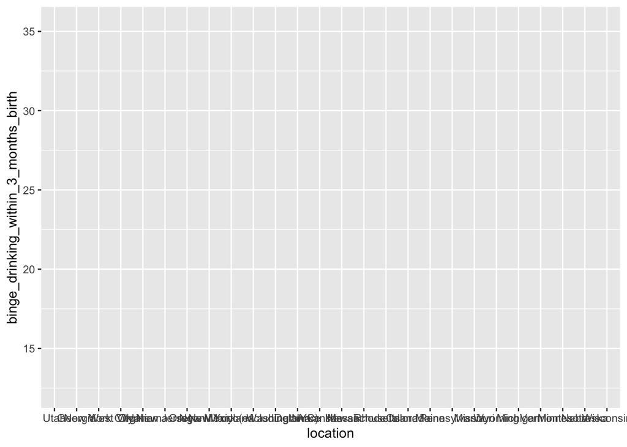

```r
prams_binge_ordered <- prams_binge_ordered |>
  mutate(location = reorder(location, binge_drinking_within_3_months_birth))

p1 <- ggplot(
  prams_binge_ordered,
  aes(x = location, y = binge_drinking_within_3_months_birth)
)

p1
```

Use `geom_col()` because the bar height is already in the data.

| Plot component | Code in this chunk |
| --- | --- |
| Geoms / stats | `geom_col()` |

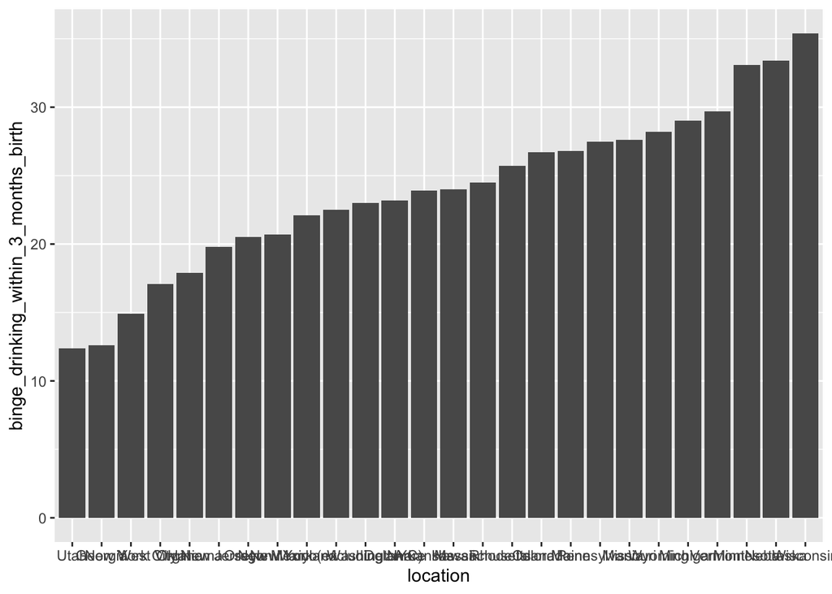

```r
p2 <- p1 +
  geom_col()

p2
```

Flip the coordinates so the location names are readable.

| Plot component | Code in this chunk |
| --- | --- |
| Scales / coordinates / facets / labels | `coord_flip()` |

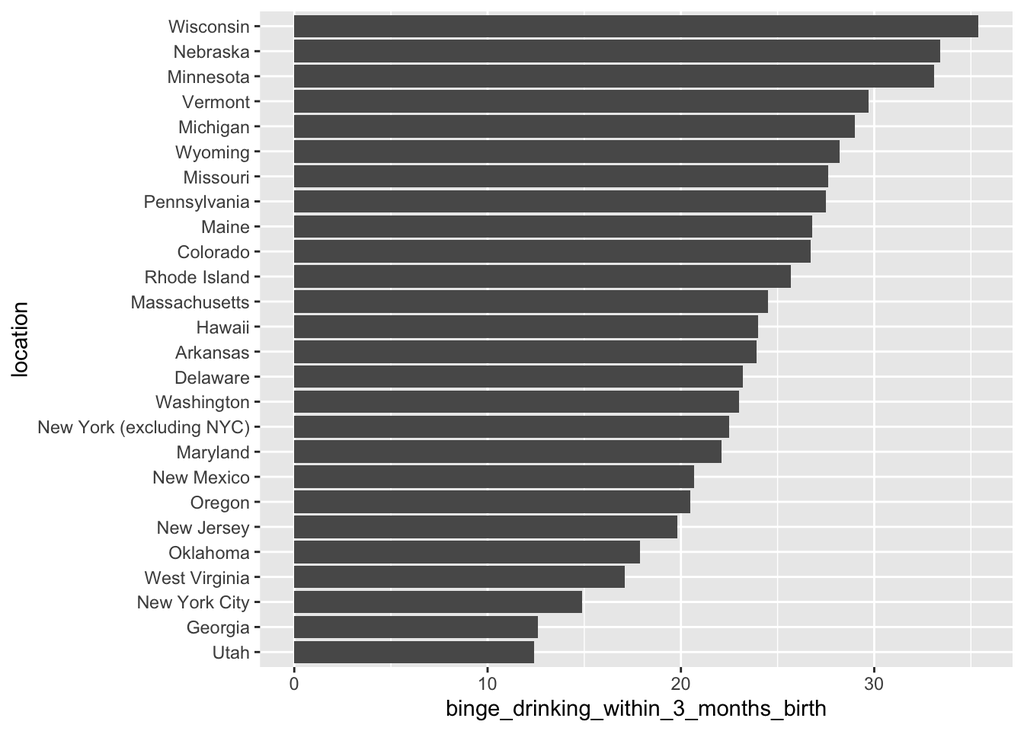

```r
p3 <- p2 +
  coord_flip()

p3
```

Add labels and a theme.

| Plot component | Code in this chunk |
| --- | --- |
| Scales / coordinates / facets / labels | `labs()`; `theme_minimal()` |

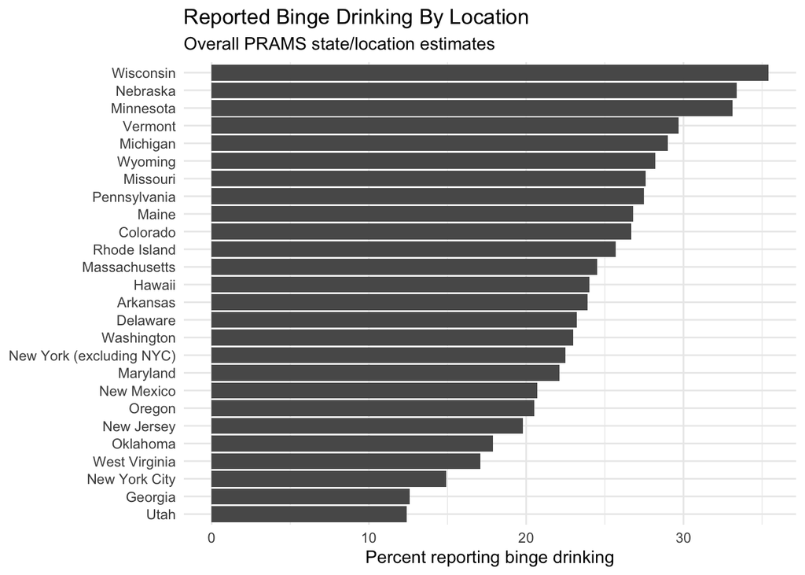

```r
p4 <- p3 +
  labs(
    title = "Reported Binge Drinking By Location",
    subtitle = "Overall PRAMS state/location estimates",
    x = NULL,
    y = "Percent reporting binge drinking"
  ) +
  theme_minimal()

p4
```

The plot compares overall location estimates, not individual people. Ordering the locations makes the higher and lower estimates easier to see.

# Plot 3: Association

Question: how are reported alcohol use and binge drinking related?

Use the same overall location estimates, then filter to places where both measures are observed.

| Data preparation step | Functions in this chunk |
| --- | --- |
| Keep or remove rows | `filter()` |
| Choose or rename columns | `select()` |

```r
prams_alcohol <- prams_overall |>
  filter(
    !is.na(alcohol_use_within_3_months_birth),
    !is.na(binge_drinking_within_3_months_birth)
  )

prams_alcohol |>
  select(
    location,
    location_abbr,
    alcohol_use_within_3_months_birth,
    binge_drinking_within_3_months_birth
  ) |>
  head()
```

```
# A tibble: 6 × 4
  location      location_abbr alcohol_use_within_3_mont…¹ binge_drinking_withi…²
  <chr>         <chr>                               <dbl>                  <dbl>
1 Arkansas      AR                                   49.6                   23.9
2 Colorado      CO                                   59.9                   26.7
3 Delaware      DE                                   54.9                   23.2
4 Georgia       GA                                   34.1                   12.6
5 Hawaii        HI                                   53.1                   24
6 Massachusetts MA                                   62.2                   24.5
# ℹ abbreviated names: ¹alcohol_use_within_3_months_birth,
#   ²binge_drinking_within_3_months_birth
```

Start with data and mappings.

| Plot component | Code in this chunk |
| --- | --- |
| Aesthetic mappings | `x`; `y` |

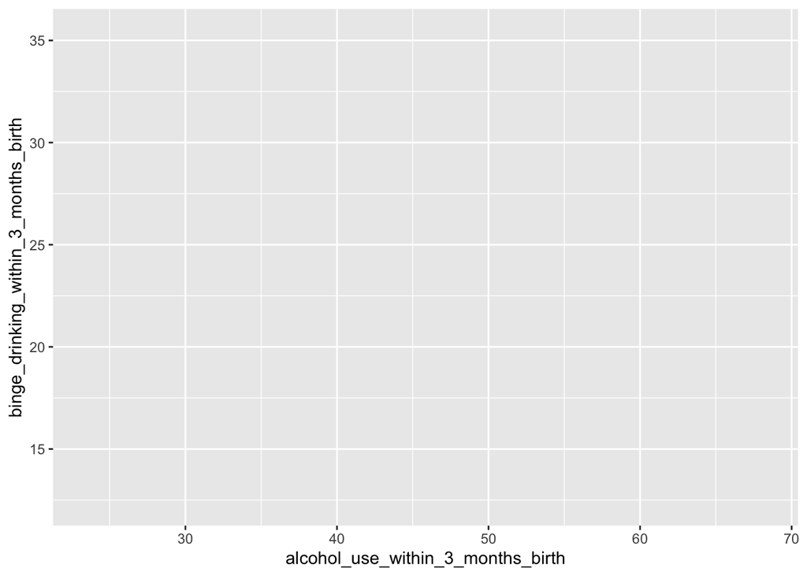

```r
p1 <- ggplot(
  prams_alcohol,
  aes(
    x = alcohol_use_within_3_months_birth,
    y = binge_drinking_within_3_months_birth
  )
)

p1
```

Add points.

| Plot component | Code in this chunk |
| --- | --- |
| Geoms / stats | `geom_point()` |

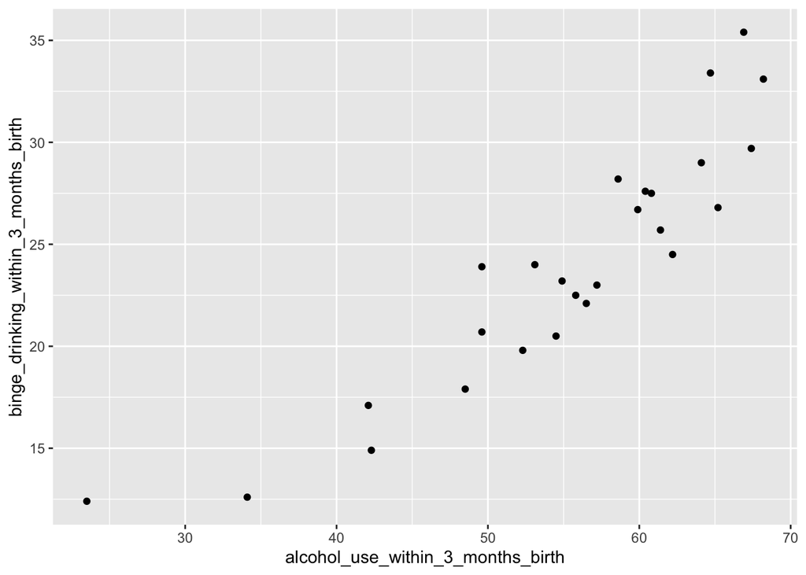

```r
p2 <- p1 +
  geom_point()

p2
```

Add transparency so overlapping points are easier to see.

| Plot component | Code in this chunk |
| --- | --- |
| `geom_point()` properties | `alpha` |

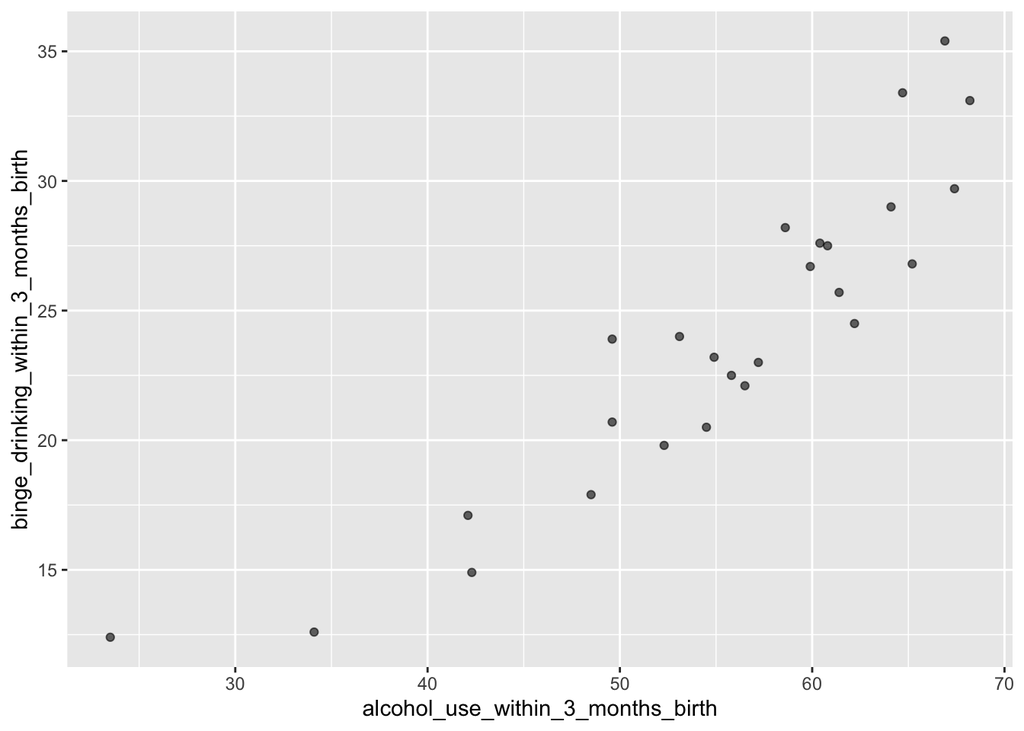

```r
p3 <- p1 +
  geom_point(alpha = 0.6)

p3
```

Add a trend line.

| Plot component | Code in this chunk |
| --- | --- |
| Geoms / stats | `geom_smooth()` |
| `geom_smooth()` properties | `method = "lm"`; `se` |

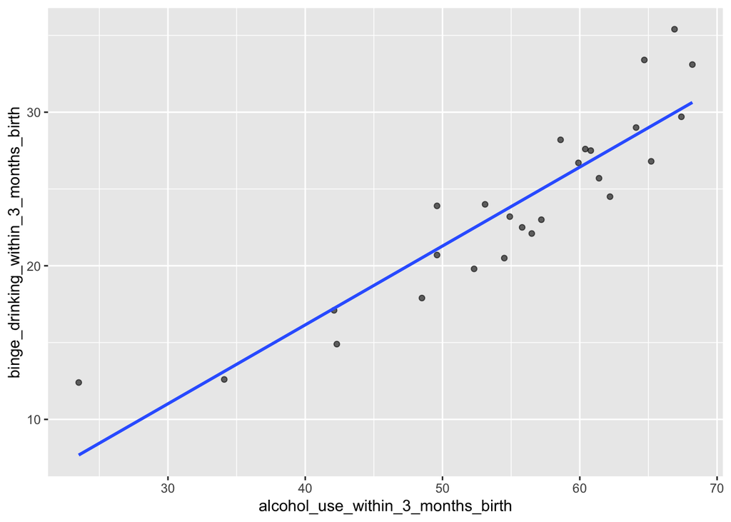

```r
p4 <- p3 +
  geom_smooth(method = "lm", se = FALSE)

p4
```

Add labels and a theme.

| Plot component | Code in this chunk |
| --- | --- |
| Scales / coordinates / facets / labels | `labs()`; `theme_minimal()` |

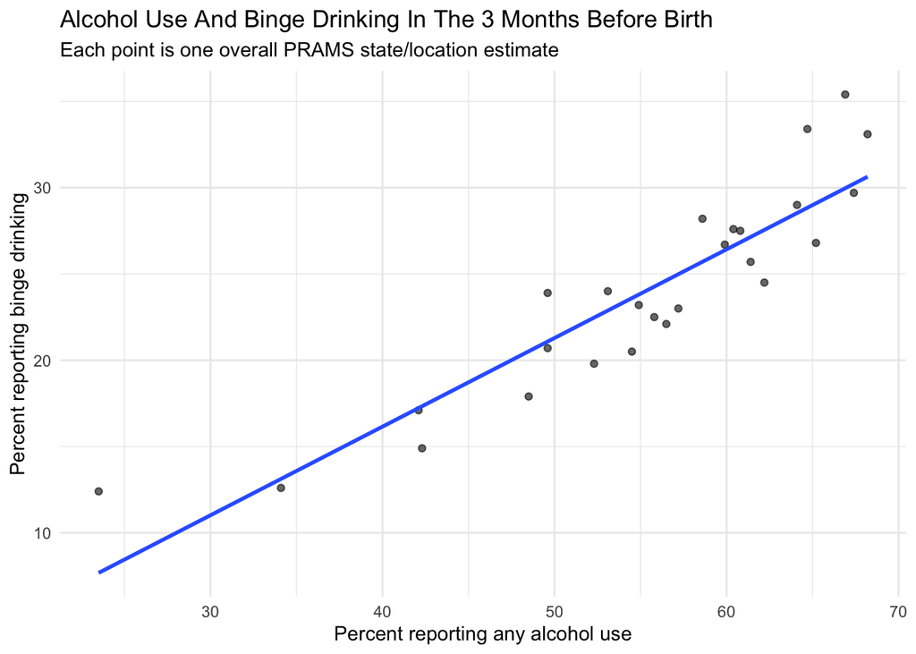

```r
p5 <- p4 +
  labs(
    title = "Alcohol Use And Binge Drinking In The 3 Months Before Birth",
    subtitle = "Each point is one overall PRAMS state/location estimate",
    x = "Percent reporting any alcohol use",
    y = "Percent reporting binge drinking"
  ) +
  theme_minimal()

p5
```

State/location estimates with higher reported alcohol use tend to have higher reported binge drinking. This is an association across pre-aggregated location estimates, not a person-level causal claim.

# Create A Flag Before Plotting

Sometimes the variable we want to plot is not already in the data. Here, we can mark which locations are above the median binge-drinking estimate.

| Data preparation step | Functions in this chunk |
| --- | --- |
| Choose or rename columns | `select()` |
| Create or change columns | `mutate()`; `if_else()` |

```r
binge_median <- median(prams_binge$binge_drinking_within_3_months_birth)

prams_binge_flagged <- prams_binge |>
  mutate(
    binge_group = if_else(
      binge_drinking_within_3_months_birth > binge_median,
      "Above median",
      "At or below median"
    ),
    location = reorder(location, binge_drinking_within_3_months_birth)
  )

prams_binge_flagged |>
  select(location, binge_drinking_within_3_months_birth, binge_group) |>
  head(10)
```

```
# A tibble: 10 × 3
   location      binge_drinking_within_3_months_birth binge_group
   <fct>                                        <dbl> <chr>
 1 Arkansas                                      23.9 At or below median
 2 Colorado                                      26.7 Above median
 3 Delaware                                      23.2 At or below median
 4 Georgia                                       12.6 At or below median
 5 Hawaii                                        24   Above median
 6 Massachusetts                                 24.5 Above median
 7 Maryland                                      22.1 At or below median
 8 Maine                                         26.8 Above median
 9 Michigan                                      29   Above median
10 Minnesota                                     33.1 Above median
```

Build a plot that uses the new flag for highlighting.

| Plot component | Code in this chunk |
| --- | --- |
| Aesthetic mappings | `x`; `y`; `fill` |

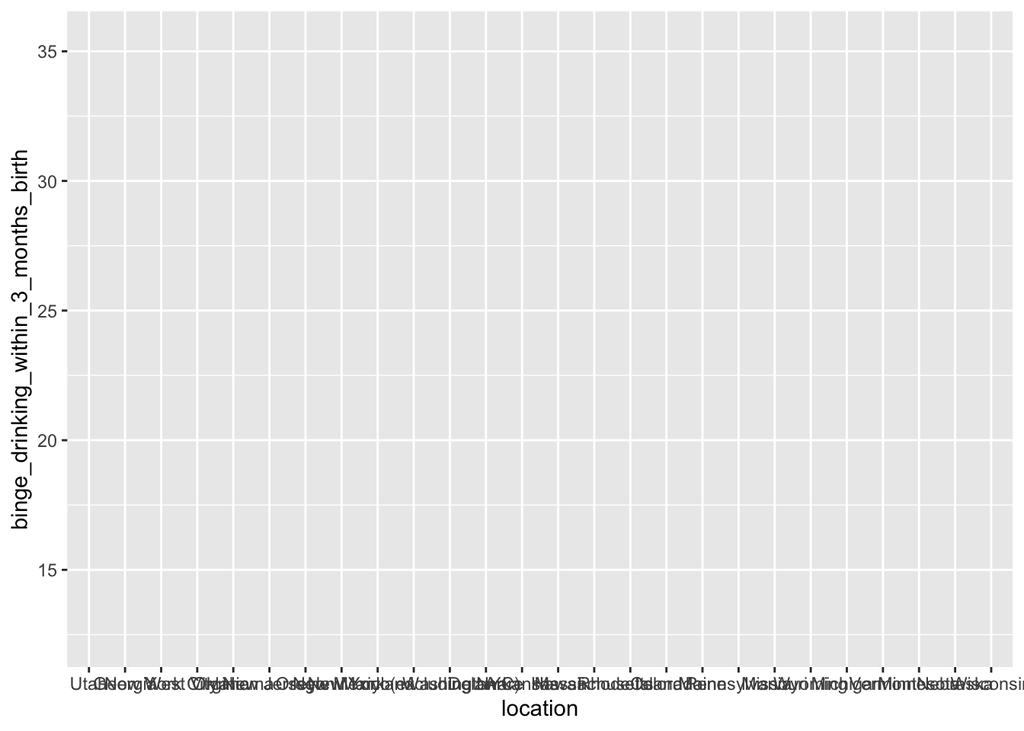

```r
p1 <- ggplot(
  prams_binge_flagged,
  aes(
    x = location,
    y = binge_drinking_within_3_months_birth,
    fill = binge_group
  )
)

p1
```

| Plot component | Code in this chunk |
| --- | --- |
| Geoms / stats | `geom_col()` |

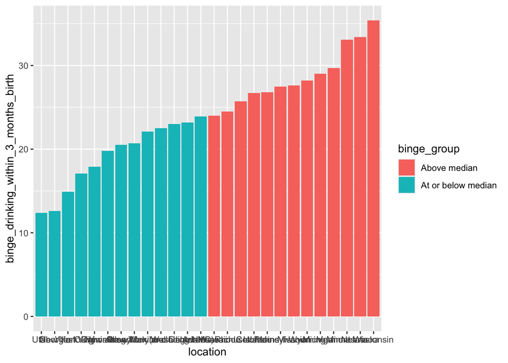

```r
p2 <- p1 +
  geom_col()

p2
```

| Plot component | Code in this chunk |
| --- | --- |
| Scales / coordinates / facets / labels | `coord_flip()` |

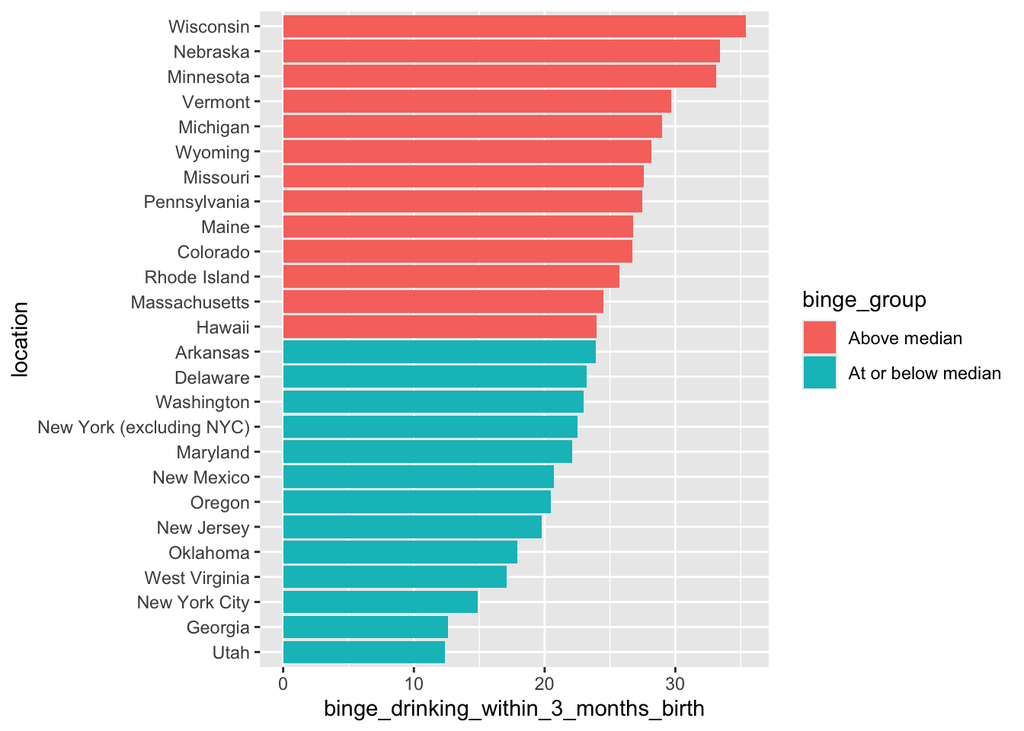

```r
p3 <- p2 +
  coord_flip()

p3
```

| Plot component | Code in this chunk |
| --- | --- |
| Scales / coordinates / facets / labels | `scale_fill_manual()`; `labs()`; `theme_minimal()` |

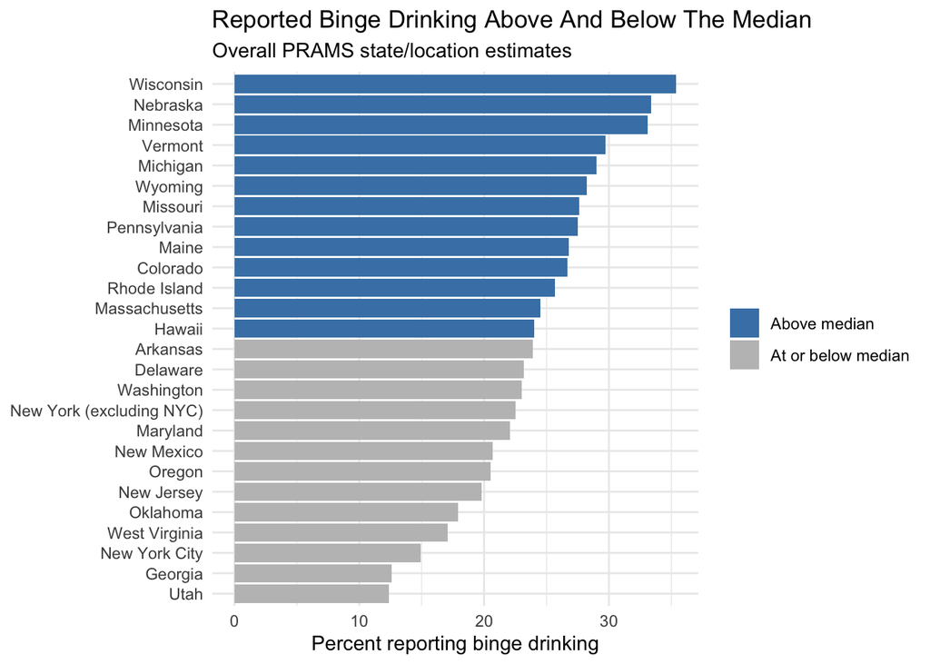

```r
p4 <- p3 +
  scale_fill_manual(
    values = c("Above median" = "steelblue", "At or below median" = "gray75")
  ) +
  labs(
    title = "Reported Binge Drinking Above And Below The Median",
    subtitle = "Overall PRAMS state/location estimates",
    x = NULL,
    y = "Percent reporting binge drinking",
    fill = NULL
  ) +
  theme_minimal()

p4
```

The new variable does not change the estimates. It changes what the figure emphasizes by separating locations above the median from the rest.

# Day 1 Pattern

The object-building pattern is:

```r
p1 <- ggplot(data, aes(...))
p1

p2 <- p1 + geom_*()
p2

p3 <- p2 + labs(...)
p3
```

This makes it easier to see what each line of code contributes to the figure.

Tomorrow we will use this same pattern for counts, summaries, ordered categories, histograms, density plots, and unusual values.

# Render Check

Render this notebook and confirm that each intermediate plot appears in the HTML output.